# Intuition Behind Histogram of Oriented Gradients (HOG)

## For a black and white image it's moderately easy to predict the digit

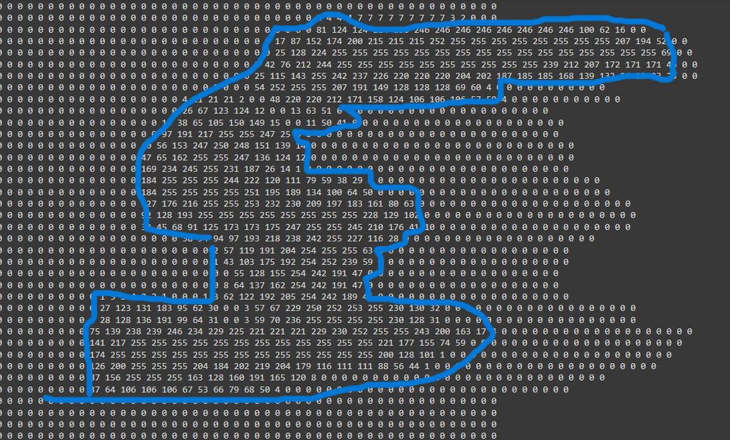

## But its difficult to predict an animal just based on the pixel values (in this case R+G+B/3) because the surrounding ,posture and other factors might also affect this

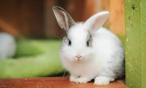

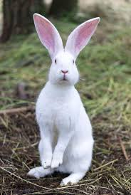

### Thus the two rabbits may be predicted as different species

## For such classifications we use HOC

### Why HOG Works ?

- Localized Information: HOG captures localized information about the gradient directions, which is crucial for detecting edges and shapes in an image.
- Invariant to Illumination: The normalization step makes HOG robust to changes in illumination and contrast, which are common in real-world images.
- Rich Descriptors: By capturing the distribution of gradient orientations, HOG provides rich descriptors that are effective for capturing the essential structure of objects.

## Now let's take an image

```python
# Load the black and white image
image_path = 'dog.jpeg'
image = cv2.imread(image_path)
plt.imshow(image)
plt.axis('off')  # Hide axis
plt.show()
```

[figure not shown]

```python
import cv2
import numpy as np
import matplotlib.pyplot as plt
from skimage.feature import hog
```

## Step 1: Image Preprocessing

### The first step is to preprocess the image to a consistent size and convert it to grayscale. Grayscale conversion reduces the complexity by converting the image to a single channel.

```python
image = cv2.imread('dog.jpeg')
# Convert to grayscale
gray_image = cv2.cvtColor(image, cv2.COLOR_BGR2GRAY)

# Display the grayscale image
plt.figure(figsize=(10, 10))
plt.subplot(221)
plt.title('Grayscale Image')
plt.imshow(gray_image, cmap='gray')
```

[figure not shown]

## Step 2: Calculate Gradient and Orientation

### Gradients represent the change in intensity of the image. They are computed using derivatives in both the x and y directions (Gx and Gy). The magnitude and orientation (angle) of the gradient are then calculated as follows:

### Magnitude= (Gx^2 + Gy^2)^1/2

### Orientation=arctan (Gy/Gx)

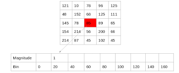

[figure not shown]

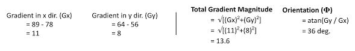

```python
# Calculate the gradients
gx = cv2.Sobel(gray_image, cv2.CV_64F, 1, 0, ksize=3)
gy = cv2.Sobel(gray_image, cv2.CV_64F, 0, 1, ksize=3)

# Calculate gradient magnitude and direction
magnitude, angle = cv2.cartToPolar(gx, gy, angleInDegrees=True)

# Display the gradient magnitude
plt.subplot(222)
plt.title('Gradient Magnitude')
plt.imshow(magnitude, cmap='gray')

# Display the gradient direction
plt.subplot(223)
plt.title('Gradient Direction')
plt.imshow(angle, cmap='gray')
```

[figure not shown]

## Step 3: Build Histogram

### Intuition:

### The image is divided into small spatial regions (cells), and for each cell, a histogram of gradient orientations is created. The idea is to capture the distribution of edge directions within each cell.

### Mathematical Explanation:

### Each pixel within a cell votes for an orientation bin based on its gradient magnitude and orientation. The histogram bins typically cover 0 to 180 or 0 to 360 degrees, depending on the implementation.

```python
# Calculate HOG features and HOG image
hog_features, hog_image = hog(gray_image, orientations=9, pixels_per_cell=(8, 8),
                              cells_per_block=(2, 2), block_norm='L2-Hys',
                              visualize=True, transform_sqrt=True)

# Display the HOG image
plt.subplot(224)
plt.title('HOG Image')
plt.imshow(hog_image, cmap='gray')

plt.tight_layout()
plt.show()
```

[figure not shown]

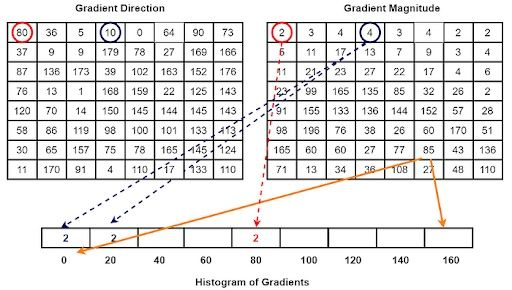

## This is what from scratch implementation of Building the histogram would look like

```python
# Calculate gradients
grad_x = cv2.Sobel(image, cv2.CV_64F, 1, 0, ksize=3)
grad_y = cv2.Sobel(image, cv2.CV_64F, 0, 1, ksize=3)

# Calculate magnitude and orientation
magnitude = cv2.magnitude(grad_x, grad_y)
orientation = cv2.phase(grad_x, grad_y, angleInDegrees=True)

plt.subplot(1, 2, 1)
plt.imshow(magnitude, cmap='gray')
plt.title('Gradient Magnitude')

plt.subplot(1, 2, 2)
plt.imshow(orientation, cmap='gray')
plt.title('Gradient Orientation')
plt.show()

# Parameters for HOG
cell_size = 8
num_bins = 9
angle_unit = 180 / num_bins

def calculate_histogram(magnitude, orientation, cell_size, num_bins):
    height, width = magnitude.shape
    histogram = np.zeros((height // cell_size, width // cell_size, num_bins))
    for i in range(0, height // cell_size):
        for j in range(0, width // cell_size):
            cell_magnitude = magnitude[i * cell_size:(i + 1) * cell_size, j * cell_size:(j + 1) * cell_size]
            cell_orientation = orientation[i * cell_size:(i + 1) * cell_size, j * cell_size:(j + 1) * cell_size]
            cell_histogram = np.zeros(num_bins)
            for p in range(cell_size):
                for q in range(cell_size):
                    bin_idx = int(cell_orientation[p, q] // angle_unit)
                    # Ensure bin_idx is within the valid range
                    bin_idx = min(bin_idx, num_bins - 1)
                    cell_histogram[bin_idx] += cell_magnitude[p, q]
            histogram[i, j, :] = cell_histogram
    return histogram

histogram = calculate_histogram(magnitude, orientation, cell_size, num_bins)

# Display histogram for a specific cell
cell_hist = histogram[0, 0, :]
plt.bar(range(num_bins), cell_hist)
plt.title('Histogram of Gradients for First Cell')
plt.xlabel('Orientation Bins')
plt.ylabel('Magnitude')
plt.show()

# Checking the histogram values for debugging
print(f"Histogram of first cell: {cell_hist}")
print(f"Sum of histogram values (should be > 0 if non-empty): {np.sum(cell_hist)}")
```

[figure not shown]

## Applications

### HOG descriptors are widely used in various computer vision tasks, including:

- Object Detection: HOG was popularized by its success in pedestrian detection, where it outperformed many existing methods.
- Image Classification: HOG features are used as input to machine learning algorithms for classifying images into different categories.
- Face Recognition: HOG can be used to extract features for recognizing faces or other objects in images.